# xwMOOC 모형

기계학습 - `gapminer` + `rsample` + `purrr`

# 1 `gapminder` 데이터

`dslabs` 팩키지에 포함된 `gapminder` 데이터셋에 결측값(NA)가 다수 포함되어 있어 결측값 패턴을 파악하고 결측값이 없는 국가만 추려 1960 ~ 2011년까지 국가별 현황을 데이터프레임으로 작성한다.

```r
> # 0. 환경설정 -----
> library(tidyverse)
> library(dslabs)
>
> # 1. 데이터 정제 -----
> gapminder_lc <- gapminder %>%
+     group_by(country) %>%
+     nest()
>
> gapminder_lc_df <- gapminder_lc %>%
+     mutate(na_cnt = map_int(data, ~ sum(is.na(.x)))) %>%
+     filter(na_cnt == 8) %>%
+     unnest(data) %>%
+     filter(year <= 2011) %>%
+     select(-na_cnt) %>%
+     select(-continent, -region)
```

# 2 기대수명 예측

`gapminder` 데이터에서 기대수명(life_expectancy)를 예측하는 기계학습 모형을 구축한다. 강건한 기대수명 예측모형 구축을 위해서 데이터를 훈련/시험데이터로 나누고, 훈련데이터는 훈련/검증데이터로 다시 나눈다. 이를 통해서 최적 모형을 식별하고 이를 예측에 활용한다.

## 2.1 훈련/검증/시험 데이터 분할

`rsample` 팩키지 `initial_split()` 함수를 사용해서 훈련:시험 데이터를 7:3으로 나누고 나서 `training()`, `testing()` 함수로 데이터를 구분시킨다. 다시, 훈련데이터는 `vfold_cv()` 함수로 다시 쪼개는데 `v = 5` 인자로 5개로 다시 나눈다.

```r
> library(rsample)
>
> ## 훈련/시험 데이터 분할
> gapminder_split <- initial_split(gapminder_lc_df, prop = 0.70)
>
> train_df <- training(gapminder_split)
> test_df  <- testing(gapminder_split)
>
> ## 훈련 데이터를 검증(Cross Validation) 데이터 분할
> gapminder_cv_split <- vfold_cv(train_df, v = 5)
>
> cv_df <- gapminder_cv_split %>%
+            mutate(train    = map(splits, ~training(.x)),
+                   validate = map(splits, ~testing(.x)))
>
> cv_df
```

```
#  5-fold cross-validation
# A tibble: 5 x 4
  splits       id    train                validate
* <list>       <chr> <list>               <list>
1 <S3: rsplit> Fold1 <tibble [2,242 x 7]> <tibble [561 x 7]>
2 <S3: rsplit> Fold2 <tibble [2,242 x 7]> <tibble [561 x 7]>
3 <S3: rsplit> Fold3 <tibble [2,242 x 7]> <tibble [561 x 7]>
4 <S3: rsplit> Fold4 <tibble [2,243 x 7]> <tibble [560 x 7]>
5 <S3: rsplit> Fold5 <tibble [2,243 x 7]> <tibble [560 x 7]>
```

## 2.2 예측모형 적합/평가

기대수명 예측은 예측값이 연속형이라 속도가 빠르면서 다른 예측모형에 대한 기준값을 제시할 수 있다는 점에서 가장 먼저 적합시켜보는 것이 의미가 있다.

훈련데이터를 훈련/검증 데이터로 5조각 냈고 각각에 대해서 `life_expectancy ~ .` 회귀식을 적합시킨다. 그리고 나서 `Metrics` 팩키지 `mae`, `rmse` 함수를 사용해서 각 검증데이터에 대한 오차를 계산하고 이를 평균내서 기준 예측오차 지표로 삼는다.

```r
> library(broom)
> library(Metrics)
>
> # 회귀모형 적합
> model_cv_df <- cv_df %>%
+     mutate(lm_model  = map(train,  ~lm(life_expectancy ~ ., data=.x)))
>
> # 회귀모형 성능 평가
> model_cv_df <- model_cv_df %>%
+     mutate(valid_actual = map(validate, ~.x$life_expectancy),
+            valid_pred   = map2(lm_model, validate, ~predict(.x, .y))) %>%
+     mutate(valid_mae    = map2_dbl(valid_actual, valid_pred, ~mae(actual = .x, predicted = .y)),
+            valid_rmse    = map2_dbl(valid_actual, valid_pred, ~rmse(actual = .x, predicted = .y)))
>
> # model_cv_df$valid_mae
> # model_cv_df$valid_rmse
>
> mean(model_cv_df$valid_rmse)
```

```
[1] 2.315179
```

```r
> mean(model_cv_df$valid_mae)
```

```
[1] 1.549939
```

## 2.3 예측모형 아키텍처

서로 다른 모형 아키텍처 회귀모형, 나무모형, SVM 모형을 적합시켜 가장 MAE가 작은 모형 아키텍처를 선정한다. 이를 통해 Random Forest를 모형 아키텍처로 잡고 모형의 성능을 더 향상시켜 보자.

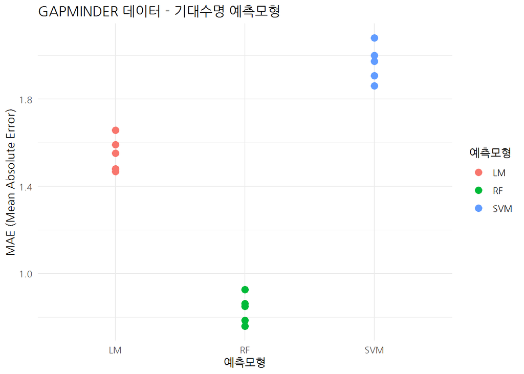

```r
> library(broom)
> library(e1071)
> library(ranger)
> library(extrafont)
> loadfonts()
>
> # 회귀모형 적합
> model_cv_df <- model_cv_df %>%
+     mutate(lm_model  = map(train,  ~lm(life_expectancy ~ ., data=.x)),
+            rf_model  = map(train,  ~ranger(life_expectancy ~ ., data=.x)),
+            svm_model = map(train,  ~svm(life_expectancy ~ ., data=.x,  probability = TRUE)))
>
> # 회귀모형 성능평가
> model_cv_df <- model_cv_df %>%
+     mutate(valid_actual = map(validate, ~.x$life_expectancy),
+            valid_lm_pred   = map2(lm_model, validate, ~predict(.x, .y)),
+            valid_rf_pred   = map2(rf_model, validate, ~predict(.x, .y)$predictions),
+            valid_svm_pred  = map2(svm_model, validate, ~predict(.x, .y))) %>%
+     mutate(valid_lm_mae    = map2_dbl(valid_actual, valid_lm_pred,  ~mae(actual = .x, predicted = .y)),
+            valid_rf_mae    = map2_dbl(valid_actual, valid_rf_pred,  ~mae(actual = .x, predicted = .y)),
+            valid_svm_mae   = map2_dbl(valid_actual, valid_svm_pred, ~mae(actual = .x, predicted = .y)))
>
>
> model_df <- data.frame(LM = model_cv_df$valid_lm_mae,
+            RF = model_cv_df$valid_rf_mae,
+            SVM = model_cv_df$valid_svm_mae)
>
> model_df %>%
+     gather(model, MAE) %>%
+     ggplot(aes(x=model, y=MAE, color=model)) +
+        geom_point(size=3) +
+        labs(x="예측모형", y="MAE (Mean Absolute Error)", color="예측모형",
+             title="GAPMINDER 데이터 - 기대수명 예측모형") +
+        theme_minimal(base_family="NanumGothic")
```

```r
> data.frame("LM_MAE_평균" = mean(model_cv_df$valid_lm_mae),
+            "RF_MAE_평균" = mean(model_cv_df$valid_rf_mae),
+            "SVM_MAE_평균" = mean(model_cv_df$valid_svm_mae))
```

```
  LM_MAE_평균 RF_MAE_평균 SVM_MAE_평균
1    1.549939   0.8365754     1.964651
```

## 2.4 예측모형 튜닝

Random Forest를 예측모형 아키텍처로 잡고 하이퍼모수(hyperparameter)를 통해 예측모형의 성능을 추가로 향상시켜본다.

```r
> # Random Forest 모형적합
> model_cv_df <- model_cv_df %>%
+     # filter(id == "Fold1") %>%
+     crossing(mtry = c(2,ceiling(sqrt(ncol(gapminder_lc_df)-2)),5), num.trees = c(500, 1000))  %>%
+     mutate(rf_tune_model  = pmap(list(train, mtry, num.trees),  ~ranger(life_expectancy ~ ., data=.x, mtry=.y)))
>
> # RandomForest 성능평가
> model_cv_df <- model_cv_df %>%
+     mutate(valid_actual = map(validate, ~.x$life_expectancy),
+            valid_rf_tune_pred   = map2(rf_tune_model, validate, ~predict(.x, .y)$predictions)) %>%
+     mutate(valid_rf_tune_mae    = map2_dbl(valid_actual, valid_rf_tune_pred,  ~mae(actual = .x, predicted = .y)))
>
> model_cv_df %>%
+     group_by(mtry, num.trees) %>%
+     summarise(mean_mae = mean(valid_rf_tune_mae))
```

```
# A tibble: 6 x 3
# Groups:   mtry [?]
   mtry num.trees mean_mae
  <dbl>     <dbl>    <dbl>
1     2       500    0.844
2     2      1000    0.836
3     3       500    0.836
4     3      1000    0.835
5     5       500    0.837
6     5      1000    0.836
```

## 2.5 예측모형 성능 평가

Random Forest 예측모형의 성능을 결정짓는데 중요한 역할을 수행하는 두가지 초모수(hyperparameter), `mtry=3`, `num.trees = 500`을 적용시켜 최종모형을 구축하고 나서 이를 시험데이터에 적용하여 과적합이 해소되었지는지 성능은 좋게 나오는지 확인한다.

```r
> gapminder_pm <- ranger(life_expectancy ~ ., data = train_df,
+                        mtry = 3, num.trees = 500)
>
> test_df$pred <- predict(gapminder_pm, test_df)$predictions
>
> test_df %>%
+     mutate(absolute_err = abs(life_expectancy-pred)) %>%
+     summarise(mae = mean(absolute_err))
```

```
# A tibble: 1 x 1
    mae
  <dbl>
1 0.759
```